```python
from IPython.display import HTML
HTML('''<script>
code_show=true;
function code_toggle() {
 if (code_show){
 $('div.input').hide();
 } else {
 $('div.input').show();
 }
 code_show = !code_show
}
$( document ).ready(code_toggle);
</script>
<form action="javascript:code_toggle()"><input type="submit" value="Click here to toggle on/off the raw code."></form>''')
```

[figure not shown]

Source: https://www.similarweb.com/corp/blog/us-elections-2016-report-bernie-sanders-getting-more-traffic-than-all-candidates-combined/

# Of the People, By the People, For the People: Predicting US presidential polls per state using Machine Learning

**Jason A. Dolorso**, Master of Science in Data Science  
Asian Institute of Management

## I. Executive Summary

With the next US presidential election set this November 3, the decision of whether Donald J Trump or Joseph R Biden Jr will sit on the oval office is just around the corner. Contrary to the usual election proces, United States employs an *Electoral College* process where electors representing each state casts the votes$^1$.

FiveThirtyEight, a leading poll analysis website, released their national polling averages ahead of the election. There are lots of presidential forecasts being published by different entities but what set FiveThirtyEight's apart is it uses aggregated polling data conducted by other firms and organizations, and also takes COVID-19 into account in their model$^2$. The site also refers to it as a *snapshot* of the current polling status for each state instead of a forecast.

This study aims to utilize features such as demographics, unemployment rate, approval rating, and previous election results, to create (1) a classifier to predict the outcome, and (2) a regressor to predict each candidates' percentages, based on FiveThirtyEight's polling averages per state.

#### Highlights

- US states are likely to vote the same party that they went for in 2016.
- Current administration's approval ratings plays a big role in predicting poll results.
- States with lower `median age` are leaned towards Trump, while higher `unemployment rate` and `asian population` are more for Biden.

## II. Data Description

The target variable would be the data for the polling average per state from FiveThirtyEight are available on their 2020 Election page$^3$:

- **`trump`**: FiveThirtyEight poll results for Trump in percentage
- **`biden`**: FiveThirtyEight poll results for Biden in percentage

The features used for the analysis are all on a per state basis:

- **`State`**: Name of the US State *
- **`unemployment`**: Unemployment rate as of June 2020 from US Bureau of Labor Statistics$^4$
- **`income`**: Annual personal income as of 2018 from Bureau of Economic Analysis$^5$

Trump's approval rating from from Civiqs:$^6$

- **`rating_approve`**: percentage of *approve* in Trump's approval rating as of Aug 2020
- **`rating_disapprove`**: percentage of *approve* in Trump's approval rating as of Aug 2020
- **`rating_neither`**: percentage of *neither* in Trump's approval rating as of Aug 2020

Demographics data from JHU Kaggle dataset$^7$

- **`Total population`**: Total population
- **`Male population`**: Total male population
- **`Female population`**: Total female population
- **`Median Age`**: States' Median Age

2016 Election Results from Harvard Dataverse$^8$

- **`2016_clinton`**: Percentage of vote for Hillary Clinton during 2016 elections
- **`2016_trump`**: Percentage of vote for Donald Trump during 2016 elections

Race and Ethnicity data as of August 20, 2020 from Governing:$^9$

- **`Hispanic (of any race)`**: Percentage of hispanic for any race
- **`Non-Hispanic White`**: Percentage of non-hispanic white
- **`Non-Hispanic Black`**: Percentage of non-hispanic black
- **`Non-Hispanic Asian`**: Percentage of non-hispanic asian
- **`Non-Hispanic American Indian`**: Percentage of non-hispanic american indian

* - NE-1 and NE-2 are for Nebraska and ME-1 and ME-2 are Maine. Both states have two electoral votes$^{10}$ and different outcome, hence the two entries.

## III. Methodology

### Pipeline

**Pre-processing**  
The only processing required for the data is to create an `outcome` target variable for the classifier based on FiveThirtyEight's poll averages, with `0` if Trump has greater percentage, and `1` if Biden. Male and Female Population are also converted to percentage by dividing it to to the total population.

**Scaling**  
To normalize the features, three scalers we're used for all models to check which ones would yield the best results: Standard Scaling, MinMax Scaling, and Robust Scaling. The results are also checked if there are no scaling applied.

**Gridsearch**  
Gridsearch was used to determine the best parameters for the classifier and regressor models. The following algorithms are explored:

- k-Nearest Neighbors
- Linear Regression - (L1 and L2)
- Logistic Regression - (L1 and L2)
- Support Vector Machine
- Random Forest
- Gradient Boosting Method

**Bootstrapping**  
To further evaluate the results of the models, bootstrapping/cross-validation is done with 1000 iterations.

**Feature Importance**  
Lastly, the importance of each features are analyzed to see what are the main factors that determines the poll results for each state.

### Setting up the Functions, Features, and the Target Variables

Let us first import the modules, the dataset, and the color scheme of Democratic and Republican Party that we'll need for this study. The outcome target variable for the classifier is also created by simply determining whether Trump or Biden has higher percentage of votes per state.

Both Male and Female Population are converted into percentages by dividing them to the total population.

```python
import pandas as pd
import numpy as np
import matplotlib.pyplot as plt
import seaborn as sns
from warnings import simplefilter
from sklearn.svm import LinearSVC
from sklearn.svm import SVC
from sklearn.svm import LinearSVR
from sklearn.model_selection import GridSearchCV, cross_val_score
from sklearn.model_selection import train_test_split
from sklearn.preprocessing import MinMaxScaler, StandardScaler, RobustScaler
from sklearn.model_selection import train_test_split
from sklearn.linear_model import Lasso
from sklearn.linear_model import Ridge
from sklearn.linear_model import LogisticRegression
from sklearn.neighbors import KNeighborsClassifier
from sklearn.neighbors import KNeighborsRegressor
from sklearn.tree import DecisionTreeClassifier
from sklearn.tree import DecisionTreeRegressor
from sklearn.ensemble import RandomForestRegressor
from sklearn.ensemble import RandomForestClassifier
from sklearn.ensemble import GradientBoostingRegressor
from sklearn.ensemble import GradientBoostingClassifier
from sklearn.exceptions import ConvergenceWarning
from sklearn.utils import resample
from sklearn.metrics import r2_score
from sklearn import tree
from sklearn.exceptions import ConvergenceWarning
from IPython.display import Image
from collections import Counter
import warnings
from warnings import simplefilter
warnings.filterwarnings("ignore", category=FutureWarning)
warnings.filterwarnings("ignore", category=RuntimeWarning)
warnings.filterwarnings("ignore", category=ConvergenceWarning)
```

```python
df = pd.read_csv('dataset.csv')
colors = ['#FF0000', '#0015BC']

df.insert(1, 'outcome', df[['trump', 'biden']].apply(
    lambda x: 0 if x['trump'] > x['biden'] else 1, axis=1))

df['Male population'] = df['Male population']/df['Total population']
df['Female Population'] = df['Female Population']/df['Total population']

df.head()
```

|  | State | outcome | trump | biden | rating_approve | rating_disapprove | rating_neither | Total population | Male population | Female Population | Median Age | income | 2016_clinton | 2016_trump | Hispanic (of any race) | Non-Hispanic White | Non-Hispanic Black | Non-Hispanic Asian | Non-Hispanic American Indian | unemployment |
| --- | --- | --- | --- | --- | --- | --- | --- | --- | --- | --- | --- | --- | --- | --- | --- | --- | --- | --- | --- | --- |
| 0 | Alabama | 0 | 57.46021 | 38.41015 | 0.56 | 0.40 | 0.04 | 4887871 | 0.484725 | 0.515275 | 39.3 | 219230 | 0.343579 | 0.620831 | 0.04 | 0.66 | 0.27 | 0.01 | 0.01 | 7.5 |
| 1 | Alaska | 0 | 49.74951 | 44.81665 | 0.44 | 0.53 | 0.04 | 737438 | 0.519301 | 0.480699 | 34.9 | 46099 | 0.365509 | 0.512815 | 0.07 | 0.61 | 0.03 | 0.07 | 0.14 | 12.4 |
| 2 | Arizona | 1 | 44.97663 | 48.65853 | 0.44 | 0.53 | 0.03 | 7171646 | 0.497114 | 0.502886 | 38.0 | 346009 | 0.451260 | 0.486716 | 0.31 | 0.55 | 0.04 | 0.03 | 0.04 | 10.0 |
| 3 | Arkansas | 0 | 46.98111 | 44.99629 | 0.62 | 0.35 | 0.03 | 3013825 | 0.489969 | 0.510031 | 38.1 | 137609 | 0.336531 | 0.605741 | 0.07 | 0.72 | 0.15 | 0.02 | 0.01 | 8.0 |
| 4 | California | 1 | 30.83791 | 61.34920 | 0.26 | 0.70 | 0.03 | 39557045 | 0.497346 | 0.502654 | 36.7 | 2701899 | 0.617264 | 0.316171 | 0.39 | 0.37 | 0.06 | 0.14 | 0.00 | 14.9 |

```python
df_features = df.drop(['State', 'trump', 'biden', 'outcome'], axis=1)
```

```python
def split(features, target, scaler = None, random_state = 0, test_size=0.25):

    X_train, X_test, y_train, y_test = train_test_split(
            features, target, test_size=test_size,
            random_state=random_state)

    scales = {'standard': StandardScaler(), 'minmax': MinMaxScaler(),
             'robust': RobustScaler()}

    if scaler != None:
        scaler = scales[scaler]

        X_train = scaler.fit_transform(X_train)
        X_test = scaler.transform(X_test)

    return X_train, X_test, y_train, y_test

def gs_knn(X_train, y_train, X_test, y_test, cv=10, verb=0):
    grid = {"n_neighbors": np.arange(1,20,2),
            "weights": ['uniform','distance'],
            'metric':['minkowski', 'euclidean', 'manhattan',]}
    knn = KNeighborsClassifier()
    knn_cv = GridSearchCV(knn, grid, cv=cv, verbose=verb)
    knn_cv.fit(X_train, y_train)

    return (knn_cv.best_score_, knn_cv.score(X_test, y_test),
            {'metrics':knn_cv.best_params_.values()})

def gs_logistic_l1(X_train, y_train, X_test, y_test,  cv=10, verb=0):

    grid = {"C": np.logspace(-3, 3, 7)}
    logreg = LogisticRegression(penalty='l1', solver='liblinear')
    logreg_cv = GridSearchCV(logreg, grid, cv=cv, verbose=verb)
    logreg_cv.fit(X_train, y_train)

    return logreg_cv.best_score_, logreg_cv.score(X_test, y_test), logreg_cv.best_params_

def gs_logistic_l2(X_train, y_train, X_test, y_test,  cv=10, verb=0):

    grid = {"C": np.logspace(-3, 3, 7)}
    logreg = LogisticRegression(penalty='l2')
    logreg_cv = GridSearchCV(logreg, grid, cv=cv, verbose=verb)
    logreg_cv.fit(X_train, y_train)

    return logreg_cv.best_score_, logreg_cv.score(X_test, y_test), logreg_cv.best_params_

def gs_lsvm_l1(X_train, y_train, X_test, y_test,  cv=10, verb = 0):

    Linear_SVC = LinearSVC(penalty='l1', dual=False)
    grid = {'C': np.logspace(-3, 2, 6)}
    svm_cv = GridSearchCV(Linear_SVC, grid, cv=cv, verbose = verb)
    svm_cv.fit(X_train, y_train)

    return svm_cv.best_score_, svm_cv.score(X_test, y_test), svm_cv.best_params_

def gs_lsvm_l2(X_train, y_train, X_test, y_test,  cv=10, verb = 0):

    Linear_SVC = LinearSVC(penalty='l2', dual=False)
    grid = {'C': np.logspace(-3, 2, 6)}
    svm_cv = GridSearchCV(Linear_SVC, grid, cv=cv, verbose = verb)
    svm_cv.fit(X_train, y_train)

    return svm_cv.best_score_, svm_cv.score(X_test, y_test), svm_cv.best_params_

def rfc(X_train, y_train, X_test, y_test,  cv=10, verb = 0):

    rfc = RandomForestClassifier()
    grid = {'n_estimators': [10, 50, 100, 200, 300],
            'max_depth':[1, 5, 10, 20, 50, 80, 100, None]}
    rfc_cv = GridSearchCV(rfc, grid, cv=cv, verbose = verb)
    rfc_cv.fit(X_train, y_train)

    return rfc_cv.best_score_, rfc_cv.score(X_test, y_test), rfc_cv.best_params_

def gbc(X_train, y_train, X_test, y_test,  cv=10, verb = 0):

    gbc = GradientBoostingClassifier()
    grid = {'n_estimators': [10, 50, 100, 200, 300],
            'max_depth':[1, 5, 10, 20, 50, 80, 100, None]}
    gbc_cv = GridSearchCV(gbc, grid, cv=cv, verbose = verb)
    gbc_cv.fit(X_train, y_train)

    return gbc_cv.best_score_, gbc_cv.score(X_test, y_test), gbc_cv.best_params_

def classify(df_features, df_target, cv=10, display_all=True):
    functions = [gs_knn, gs_logistic_l1, gs_logistic_l2, gs_lsvm_l1,
                gs_lsvm_l2, rfc, gbc]
    scaler = [None, 'standard', 'minmax', 'robust']

    top_model = []
    top_acc = []
    top_acc_test = []
    top_par = []

    for scale in scaler:
        X_train, X_test, y_train, y_test = split(
            df_features, df_target, scale)
        model = ['KNN', 'Logistic Regression (L1)',
                 'Logistic Regression (L2)', 'SVC (L1)', 'SVC (L2)',
                 'Random Forest', 'Gradient Boosting']
        accuracy = []
        accuracy_test = []
        parameters = []

        for fn in functions:
            acc_train, acc_test, par = fn(
                X_train, y_train, X_test, y_test, cv)
            accuracy += [acc_train]
            accuracy_test += [acc_test]
            parameters += [par]

        results = pd.DataFrame({'Model '+f'(scale: {scale})':model,
                                'Train accuracy':accuracy,
                                'Test accuracy':accuracy_test,
                                'Best Parameters': parameters}
                              ).set_index('Model '+f'(scale: {scale})')
        if display_all:
            display(results)

        best = results.reset_index().sort_values(
            'Test accuracy', ascending=False)
        top_model += [best.iloc[0,0]]
        top_acc += [best.iloc[0,1]]
        top_acc_test += [best.iloc[0,2]]
        top_par += [best.iloc[0,3]]

    top = pd.DataFrame({'Scale':scaler, 'Model':top_model,
                       'Train Accuracy':top_acc, 'Test Accuracy':top_acc_test,
                        'Parameters':top_par})
    display(top.set_index('Scale'))
```

```python
def split(features, target, scaler = None, random_state = 0, test_size=0.25):

    X_train, X_test, y_train, y_test = train_test_split(
            features, target, test_size=test_size,
            random_state=random_state)

    scales = {'standard': StandardScaler(), 'minmax': MinMaxScaler(),
             'robust': RobustScaler()}

    if scaler != None:
        scaler = scales[scaler]

        X_train = scaler.fit_transform(X_train)
        X_test = scaler.transform(X_test)

    return X_train, X_test, y_train, y_test

def gs_knn(X_train, y_train, X_test, y_test, cv=10, verb=0):
    grid = {"n_neighbors": np.arange(1,20,2),
            "weights": ['uniform','distance'],
            'metric':['minkowski', 'euclidean', 'manhattan',]}
    knn = KNeighborsRegressor()
    knn_cv = GridSearchCV(knn, grid, cv=cv, verbose=verb)
    knn_cv.fit(X_train, y_train)

    return (knn_cv.best_score_, knn_cv.score(X_test, y_test),
            {'metrics':knn_cv.best_params_.values()})

def gs_linear_l1(X_train, y_train, X_test, y_test,  cv=10, verb=0):

    grid = {"alpha": [0.001, 0.005, 0.01, 0.02, 0.03, 0.05, 0.08, 0.1, 1, 10]}
    lasso = Lasso()
    lasso_cv = GridSearchCV(lasso, grid, cv=cv, verbose=verb)
    lasso_cv.fit(X_train, y_train)

    return lasso_cv.best_score_, lasso_cv.score(X_test, y_test), lasso_cv.best_params_

def gs_linear_l2(X_train, y_train, X_test, y_test,  cv=10, verb=0):

    grid = {"alpha": [0.001, 0.005, 0.01, 0.02, 0.03, 0.05, 0.08, 0.1, 1, 10]}
    ridge = Ridge()
    ridge_cv = GridSearchCV(ridge, grid, cv=cv, verbose=verb)
    ridge_cv.fit(X_train, y_train)

    return ridge_cv.best_score_, ridge_cv.score(X_test, y_test), ridge_cv.best_params_

def gs_lsvm_l1(X_train, y_train, X_test, y_test,  cv=10, verb = 0):

    Linear_SVR = LinearSVR(loss='epsilon_insensitive')
    grid = {'C': np.logspace(-3, 2, 6)}
    svr_cv = GridSearchCV(Linear_SVR, grid, cv=cv, verbose = verb)
    svr_cv.fit(X_train, y_train)

    return svr_cv.best_score_, svr_cv.score(X_test, y_test), svr_cv.best_params_

def gs_lsvm_l2(X_train, y_train, X_test, y_test,  cv=10, verb = 0):

    Linear_SVR = LinearSVR(loss='squared_epsilon_insensitive')
    grid = {'C': np.logspace(-3, 2, 6)}
    svr_cv = GridSearchCV(Linear_SVR, grid, cv=cv, verbose = verb)
    svr_cv.fit(X_train, y_train)

    return svr_cv.best_score_, svr_cv.score(X_test, y_test), svr_cv.best_params_

def rfr(X_train, y_train, X_test, y_test, cv=10, verb = 0):

    rfr = RandomForestRegressor()
    grid = {'n_estimators': [10, 50, 100, 200, 300],
            'max_depth':[1, 5, 10, 20, 50, 80, 100, None]}
    rfr_cv = GridSearchCV(rfr, grid, cv=cv, verbose = verb)
    rfr_cv.fit(X_train, y_train)

    return rfr_cv.best_score_, rfr_cv.score(X_test, y_test), rfr_cv.best_params_

def gbr(X_train, y_train, X_test, y_test,  cv=10, verb = 0):

    gbr = GradientBoostingRegressor()
    grid = {'n_estimators': [10, 50, 100, 200, 300],
            'max_depth':[1, 5, 10, 20, 50, 80, 100, None]}
    gbr_cv = GridSearchCV(gbr, grid, cv=cv, verbose = verb)
    gbr_cv.fit(X_train, y_train)

    return gbr_cv.best_score_, gbr_cv.score(X_test, y_test), gbr_cv.best_params_

def regressor(df_features, df_target, cv=10, display_all=True):
    functions = [gs_knn, gs_linear_l1, gs_linear_l2, gs_lsvm_l1,
                gs_lsvm_l2, rfr, gbr]
    scaler = [None, 'standard', 'minmax', 'robust']

    top_model = []
    top_acc = []
    top_acc_test = []
    top_par = []

    for scale in scaler:
        X_train, X_test, y_train, y_test = split(
            df_features, df_target, scale)
        model = ['KNN', 'Linear Regression (L1)',
                 'Linear Regression (L2)', 'SVC (L1)', 'SVC (L2)',
                 'Random Forest', 'Gradient Boosting']
        accuracy = []
        accuracy_test = []
        parameters = []

        for fn in functions:
            acc_train, acc_test, par = fn(
                X_train, y_train, X_test, y_test, cv)
            accuracy += [acc_train]
            accuracy_test += [acc_test]
            parameters += [par]

        results = pd.DataFrame({'Model '+f'(scale: {scale})':model,
                                'Train accuracy':accuracy,
                                'Test accuracy':accuracy_test,
                                'Best Parameters': parameters}
                              ).set_index('Model '+f'(scale: {scale})')
        if display_all:
            display(results)

        best = results.reset_index().sort_values(
            'Test accuracy', ascending=False)
        top_model += [best.iloc[0,0]]
        top_acc += [best.iloc[0,1]]
        top_acc_test += [best.iloc[0,2]]
        top_par += [best.iloc[0,3]]

    top = pd.DataFrame({'Scale':scaler, 'Model':top_model,
                       'Train Accuracy':top_acc, 'Test Accuracy':top_acc_test,
                        'Parameters':top_par})
    display(top.set_index('Scale'))
```

### Outcome Classifier

```
Population per class:     0
0  21
1  25

1.25 * Proportion Chance Criterion: 62.97258979206048%
```

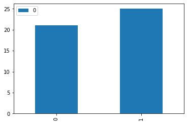

```python
state_counts = Counter(df['outcome'])
df_state = pd.DataFrame.from_dict(state_counts, orient='index')
df_state.plot(kind='bar')

num=(df_state[0]/df_state[0].sum())**2
print("Population per class: {}\n".format(df_state))
print("1.25 * Proportion Chance Criterion: {}%".format(1.25*100*num.sum()))
```

To evaluate the performance of the classifier, we'll use Proportion Chance Criterion (PPC) x 1.25 which is 62.97%. The classifier needs to have an accuracy above that threshold to be considered *valid*.

```python
classify(df_features, df['outcome'])
```

| Model (scale: None) | Train accuracy | Test accuracy | Best Parameters |
| --- | --- | --- | --- |
| KNN | -0.066897 | -0.205450 | {'metrics': ('minkowski', 17, 'uniform')} |
| Logistic Regression (L1) | 0.833333 | 0.916667 | {'C': 10.0} |
| Logistic Regression (L2) | 0.658333 | 0.833333 | {'C': 0.001} |
| SVC (L1) | -1.162329 | -708.981405 | {'C': 10.0} |
| SVC (L2) | -1.197305 | -710.551225 | {'C': 100.0} |
| Random Forest | 0.908333 | 0.916667 | {'max_depth': 1, 'n_estimators': 300} |
| Gradient Boosting | 0.883333 | 0.916667 | {'max_depth': 1, 'n_estimators': 10} |

| Model (scale: standard) | Train accuracy | Test accuracy | Best Parameters |
| --- | --- | --- | --- |
| KNN | 0.450000 | -0.125000 | {'metrics': ('minkowski', 1, 'uniform')} |
| Logistic Regression (L1) | 0.891667 | 0.916667 | {'C': 0.1} |
| Logistic Regression (L2) | 0.925000 | 0.916667 | {'C': 0.1} |
| SVC (L1) | 0.029278 | 0.225321 | {'C': 0.1} |
| SVC (L2) | 0.202506 | 0.061702 | {'C': 0.1} |
| Random Forest | 0.891667 | 0.916667 | {'max_depth': 1, 'n_estimators': 10} |
| Gradient Boosting | 0.883333 | 0.916667 | {'max_depth': 1, 'n_estimators': 10} |

| Model (scale: minmax) | Train accuracy | Test accuracy | Best Parameters |
| --- | --- | --- | --- |
| KNN | 0.450000 | -0.125000 | {'metrics': ('minkowski', 1, 'uniform')} |
| Logistic Regression (L1) | 0.891667 | 0.916667 | {'C': 1.0} |
| Logistic Regression (L2) | 0.916667 | 0.916667 | {'C': 0.1} |
| SVC (L1) | 0.320081 | 0.235678 | {'C': 0.1} |
| SVC (L2) | 0.262468 | 0.381999 | {'C': 0.1} |
| Random Forest | 0.908333 | 0.833333 | {'max_depth': 20, 'n_estimators': 10} |
| Gradient Boosting | 0.883333 | 0.916667 | {'max_depth': 1, 'n_estimators': 10} |

| Model (scale: robust) | Train accuracy | Test accuracy | Best Parameters |
| --- | --- | --- | --- |
| KNN | 0.494669 | 0.284732 | {'metrics': ('minkowski', 3, 'distance')} |
| Logistic Regression (L1) | 0.925000 | 0.916667 | {'C': 1.0} |
| Logistic Regression (L2) | 0.875000 | 0.916667 | {'C': 0.1} |
| SVC (L1) | -0.094723 | 0.242694 | {'C': 0.1} |
| SVC (L2) | -0.061944 | 0.293789 | {'C': 0.1} |
| Random Forest | 0.908333 | 0.916667 | {'max_depth': 1, 'n_estimators': 200} |
| Gradient Boosting | 0.883333 | 0.916667 | {'max_depth': 1, 'n_estimators': 10} |

| Scale | Model | Train Accuracy | Test Accuracy | Parameters |
| --- | --- | --- | --- | --- |
| NaN | Logistic Regression (L1) | 0.833333 | 0.916667 | {'C': 10.0} |
| standard | Logistic Regression (L1) | 0.891667 | 0.916667 | {'C': 0.1} |
| minmax | Logistic Regression (L1) | 0.891667 | 0.916667 | {'C': 1.0} |
| robust | Logistic Regression (L1) | 0.925000 | 0.916667 | {'C': 1.0} |

The results for the classifier shows that Logistic Regression with L-1 penalty have the best test accuracy of **91.67%** for all types of scaling. But Logistic Regression for Robust scaling are deemed to be the best as it also have the best train accuracy of **92.50%**.

### Regressor for Trump votes

```python
regressor(df_features, df['trump'])
```

| Model (scale: None) | Train accuracy | Test accuracy | Best Parameters |
| --- | --- | --- | --- |
| KNN | -0.310411 | -0.326138 | {'metrics': ('manhattan', 3, 'distance')} |
| Linear Regression (L1) | 0.723250 | 0.576747 | {'alpha': 0.03} |
| Linear Regression (L2) | 0.759676 | 0.773603 | {'alpha': 0.02} |
| SVC (L1) | -85.071591 | -229.094499 | {'C': 10.0} |
| SVC (L2) | -71.288911 | -136.627936 | {'C': 10.0} |
| Random Forest | 0.629998 | 0.796225 | {'max_depth': 80, 'n_estimators': 50} |
| Gradient Boosting | 0.606328 | 0.821026 | {'max_depth': 1, 'n_estimators': 50} |

| Model (scale: standard) | Train accuracy | Test accuracy | Best Parameters |
| --- | --- | --- | --- |
| KNN | 0.604634 | 0.731043 | {'metrics': ('manhattan', 3, 'uniform')} |
| Linear Regression (L1) | 0.699491 | 0.908113 | {'alpha': 1} |
| Linear Regression (L2) | 0.729601 | 0.761880 | {'alpha': 10} |
| SVC (L1) | 0.564923 | 0.702011 | {'C': 10.0} |
| SVC (L2) | 0.479303 | 0.790976 | {'C': 1.0} |
| Random Forest | 0.635211 | 0.824442 | {'max_depth': None, 'n_estimators': 100} |
| Gradient Boosting | 0.651940 | 0.794955 | {'max_depth': 1, 'n_estimators': 50} |

| Model (scale: minmax) | Train accuracy | Test accuracy | Best Parameters |
| --- | --- | --- | --- |
| KNN | 0.599210 | 0.769381 | {'metrics': ('manhattan', 5, 'uniform')} |
| Linear Regression (L1) | 0.718733 | 0.885451 | {'alpha': 0.1} |
| Linear Regression (L2) | 0.726093 | 0.797698 | {'alpha': 1} |
| SVC (L1) | 0.681666 | 0.823020 | {'C': 10.0} |
| SVC (L2) | 0.688265 | 0.784765 | {'C': 1.0} |
| Random Forest | 0.661081 | 0.759461 | {'max_depth': None, 'n_estimators': 10} |
| Gradient Boosting | 0.654663 | 0.769000 | {'max_depth': 1, 'n_estimators': 50} |

| Model (scale: robust) | Train accuracy | Test accuracy | Best Parameters |
| --- | --- | --- | --- |
| KNN | 0.547752 | 0.774502 | {'metrics': ('manhattan', 3, 'uniform')} |
| Linear Regression (L1) | 0.667502 | 0.852624 | {'alpha': 0.1} |
| Linear Regression (L2) | 0.687382 | 0.763151 | {'alpha': 1} |
| SVC (L1) | 0.660352 | 0.439006 | {'C': 10.0} |
| SVC (L2) | 0.465928 | 0.667151 | {'C': 1.0} |
| Random Forest | 0.641227 | 0.793671 | {'max_depth': 80, 'n_estimators': 100} |
| Gradient Boosting | 0.637293 | 0.820643 | {'max_depth': 1, 'n_estimators': 50} |

| Scale | Model | Train Accuracy | Test Accuracy | Parameters |
| --- | --- | --- | --- | --- |
| NaN | Gradient Boosting | 0.606328 | 0.821026 | {'max_depth': 1, 'n_estimators': 50} |
| standard | Linear Regression (L1) | 0.699491 | 0.908113 | {'alpha': 1} |
| minmax | Linear Regression (L1) | 0.718733 | 0.885451 | {'alpha': 0.1} |
| robust | Linear Regression (L1) | 0.667502 | 0.852624 | {'alpha': 0.1} |

Lasso Regression, or Linear Regression with L-1 penalty, with standard scaling is the best model for predicting states' vote for Trump, with an r-score of **90.81%**.

### Regressor for Biden votes

```python
regressor(df_features, df['biden'])
```

| Model (scale: None) | Train accuracy | Test accuracy | Best Parameters |
| --- | --- | --- | --- |
| KNN | -0.523564 | -0.141685 | {'metrics': ('manhattan', 15, 'uniform')} |
| Linear Regression (L1) | 0.599709 | 0.591508 | {'alpha': 0.02} |
| Linear Regression (L2) | 0.694088 | 0.466946 | {'alpha': 0.05} |
| SVC (L1) | -80.375110 | -179.707871 | {'C': 0.001} |
| SVC (L2) | -127.984825 | -299.113777 | {'C': 0.1} |
| Random Forest | 0.675426 | 0.672542 | {'max_depth': None, 'n_estimators': 50} |
| Gradient Boosting | 0.670605 | 0.702320 | {'max_depth': 1, 'n_estimators': 50} |

| Model (scale: standard) | Train accuracy | Test accuracy | Best Parameters |
| --- | --- | --- | --- |
| KNN | 0.480883 | 0.563771 | {'metrics': ('manhattan', 3, 'uniform')} |
| Linear Regression (L1) | 0.596954 | 0.789336 | {'alpha': 1} |
| Linear Regression (L2) | 0.675798 | 0.112598 | {'alpha': 10} |
| SVC (L1) | 0.452844 | 0.555200 | {'C': 10.0} |
| SVC (L2) | 0.421109 | 0.317891 | {'C': 1.0} |
| Random Forest | 0.696743 | 0.663732 | {'max_depth': 5, 'n_estimators': 10} |
| Gradient Boosting | 0.651707 | 0.728714 | {'max_depth': 1, 'n_estimators': 50} |

| Model (scale: minmax) | Train accuracy | Test accuracy | Best Parameters |
| --- | --- | --- | --- |
| KNN | 0.517388 | 0.621010 | {'metrics': ('manhattan', 7, 'uniform')} |
| Linear Regression (L1) | 0.619991 | 0.679987 | {'alpha': 0.05} |
| Linear Regression (L2) | 0.696004 | 0.309289 | {'alpha': 1} |
| SVC (L1) | 0.691231 | -0.142035 | {'C': 10.0} |
| SVC (L2) | 0.635997 | 0.235494 | {'C': 10.0} |
| Random Forest | 0.681899 | 0.662108 | {'max_depth': 5, 'n_estimators': 50} |
| Gradient Boosting | 0.673343 | 0.725062 | {'max_depth': 1, 'n_estimators': 50} |

| Model (scale: robust) | Train accuracy | Test accuracy | Best Parameters |
| --- | --- | --- | --- |
| KNN | 0.440021 | 0.556845 | {'metrics': ('manhattan', 5, 'uniform')} |
| Linear Regression (L1) | 0.577441 | 0.485746 | {'alpha': 0.1} |
| Linear Regression (L2) | 0.646816 | -0.430378 | {'alpha': 10} |
| SVC (L1) | 0.473564 | -0.464331 | {'C': 10.0} |
| SVC (L2) | 0.520973 | 0.269004 | {'C': 1.0} |
| Random Forest | 0.678410 | 0.702505 | {'max_depth': 5, 'n_estimators': 50} |
| Gradient Boosting | 0.676297 | 0.699775 | {'max_depth': 1, 'n_estimators': 50} |

| Scale | Model | Train Accuracy | Test Accuracy | Parameters |
| --- | --- | --- | --- | --- |
| NaN | Gradient Boosting | 0.670605 | 0.702320 | {'max_depth': 1, 'n_estimators': 50} |
| standard | Linear Regression (L1) | 0.596954 | 0.789336 | {'alpha': 1} |
| minmax | Gradient Boosting | 0.673343 | 0.725062 | {'max_depth': 1, 'n_estimators': 50} |
| robust | Random Forest | 0.678410 | 0.702505 | {'max_depth': 5, 'n_estimators': 50} |

Similarly, Lasso Regression also has the best results for Biden's votes.

## IV. Results

### Evaluating Results (Bootstrapping)

Since our dataset is relatively small, we can use bootstrapping to evaluate the results of each model for the classifier and two regressors, that yielded the best accuracy from our gridsearch.

```python
boot_clf_train = []
boot_clf_test = []
samples = 40
sim_size = 1000
drop = ['State', 'outcome', 'trump', 'biden']
scaler = RobustScaler()

for x in range(sim_size):
    boot = resample(df, replace=True, n_samples=samples, random_state=x)
    oob = [x for x in list(df['State']) if x not in list(boot['State'])]
    oob = df[df['State'].isin(oob)]

    X_train = boot.drop(drop, axis=1)
    y_train = boot['outcome']
    X_test = oob.drop(drop, axis=1)
    y_test = oob['outcome']

    X_train = scaler.fit_transform(X_train)
    X_test = scaler.transform(X_test)

    logreg = LogisticRegression(penalty='l1', solver='liblinear', C=1.0)
    logreg.fit(X_train, y_train)
    boot_clf_train += [logreg.score(X_train, y_train)]
    boot_clf_test += [logreg.score(X_test, y_test)]

print('Classifier: Logistic L1 with Robust Scaling')
print(f'Train Accuracy Mean: {np.mean(boot_clf_train)}')
print(f'Test Accuracy Mean: {np.mean(boot_clf_test)}')
print(f'Test Accuracy Standard Deviation: {np.std(boot_clf_test)}')
```

```
Classifier: Logistic L1 with Robust Scaling
Train Accuracy Mean: 0.9494499999999999
Test Accuracy Mean: 0.8370551058815402
Test Accuracy Standard Deviation: 0.08013054422239474
```

```python
boot_reg_train_trump = []
boot_reg_test_trump = []
samples = 40
sim_size = 1000
drop = ['State', 'outcome', 'trump', 'biden']
scaler = StandardScaler()

for x in range(sim_size):
    boot = resample(df, replace=True, n_samples=samples, random_state=x)
    oob = [x for x in list(df['State']) if x not in list(boot['State'])]
    oob = df[df['State'].isin(oob)]

    X_train = boot.drop(drop, axis=1)
    y_train = boot['trump']
    X_test = oob.drop(drop, axis=1)
    y_test = oob['trump']

    X_train = scaler.fit_transform(X_train)
    X_test = scaler.transform(X_test)

    lasso = Lasso(alpha=1)
    lasso.fit(X_train, y_train)
    boot_reg_train_trump += [lasso.score(X_train, y_train)]
    boot_reg_test_trump += [lasso.score(X_test, y_test)]

print('Trump Votes Regressor: Lasso Regression with Standard Scaling')
print(f'Train Accuracy Mean: {np.mean(boot_reg_train_trump)}')
print(f'Test Accuracy Mean: {np.mean(boot_reg_test_trump)}')
print(f'Test Accuracy Standard Deviation: {np.std(boot_reg_test_trump)}')
```

```
Trump Votes Regressor: Lasso Regression with Standard Scaling
Train Accuracy Mean: 0.8813378071330923
Test Accuracy Mean: 0.8274345953212444
Test Accuracy Standard Deviation: 0.05709369578948694
```

```python
boot_reg_train_biden = []
boot_reg_test_biden = []
samples = 40
sim_size = 1000
drop = ['State', 'outcome', 'trump', 'biden']
scaler = StandardScaler()

for x in range(sim_size):
    boot = resample(df, replace=True, n_samples=samples, random_state=x)
    oob = [x for x in list(df['State']) if x not in list(boot['State'])]
    oob = df[df['State'].isin(oob)]

    X_train = boot.drop(drop, axis=1)
    y_train = boot['biden']
    X_test = oob.drop(drop, axis=1)
    y_test = oob['biden']

    X_train = scaler.fit_transform(X_train)
    X_test = scaler.transform(X_test)

    lasso = Lasso(alpha=1)
    lasso.fit(X_train, y_train)
    boot_reg_train_biden += [lasso.score(X_train, y_train)]
    boot_reg_test_biden += [lasso.score(X_test, y_test)]

print('Biden Votes Regressor: Lasso Regression with Standard Scaling')
print(f'Train Accuracy Mean: {np.mean(boot_reg_train_biden)}')
print(f'Test Accuracy Mean: {np.mean(boot_reg_test_biden)}')
print(f'Test Accuracy Standard Deviation: {np.std(boot_reg_test_biden)}')
```

```
Biden Votes Regressor: Lasso Regression with Standard Scaling
Train Accuracy Mean: 0.840153410540308
Test Accuracy Mean: 0.7293003336986786
Test Accuracy Standard Deviation: 0.1044529434426854
```

The table below summarizes the results of the bootstrapping with 1000 iterations used:

[output not shown]

### Feature Importance

To further analyze the results, let's take a look at the most important features for each model.

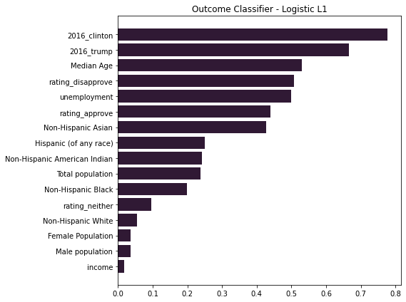

```python
X_train, X_test, y_train, y_test = train_test_split(
        df_features, df['outcome'], test_size=0.25, random_state=1)

scaler = RobustScaler()
X_train = scaler.fit_transform(X_train)
X_test = scaler.transform(X_test)

lr = LogisticRegression(C=1)
# logreg = logreg(alpha=1)
lr.fit(X_train, y_train)

coefs = lr.coef_

top_predictor=df_features.columns[np.argmax(np.abs(coefs))]
abs_coefs = np.abs(coefs[0,:])
coefs_count = len(abs_coefs)
fig, ax = plt.subplots(figsize=(8,6))
ax.barh(np.arange(coefs_count), sorted(abs_coefs), color='#301934')
ax.set_yticks(np.arange(coefs_count))
ax.set_yticklabels(df_features.columns[np.argsort(abs_coefs)])
ax.set_title('Outcome Classifier - Logistic L1');
plt.tight_layout()
# fig.savefig('importance.png', transparent=True)
```

The chart above shows that `results of 2016 elections` (state's vote for clinton/trump) are the most important features to predict the poll's outcome on each state. Meanwhile, `median age`, `unemployment`, and `rating approvals` comes next. On the other hand, the number of `non-hispanic asian` is the most important among all race/ethnicity features.

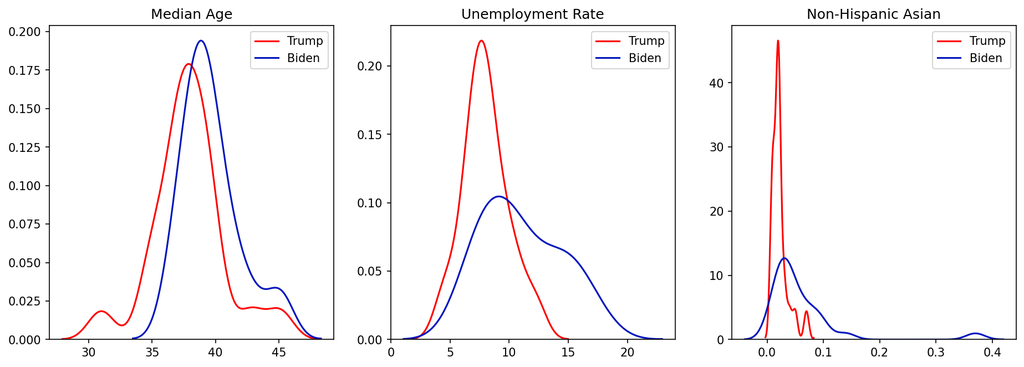

```python
# Sort the dataframe by target
target_0 = df.loc[df['outcome'] == 0]
target_1 = df.loc[df['outcome'] == 1]

fig, ax = plt.subplots(ncols = 3, figsize=(15,5), dpi=150)

sns.distplot(target_0[['Median Age']], hist=False, color=colors[0], label='Trump', ax=ax[0])
sns.distplot(target_1[['Median Age']], hist=False, color=colors[1], label='Biden', ax=ax[0])

sns.distplot(target_0[['unemployment']], hist=False, color=colors[0], label='Trump', ax=ax[1])
sns.distplot(target_1[['unemployment']], hist=False, color=colors[1], label='Biden', ax=ax[1])

sns.distplot(target_0[['Non-Hispanic Asian']], hist=False, color=colors[0], label='Trump', ax=ax[2])
sns.distplot(target_1[['Non-Hispanic Asian']], hist=False, color=colors[1], label='Biden', ax=ax[2])

ax[0].set_title('Median Age')
ax[1].set_title('Unemployment Rate')
ax[2].set_title('Non-Hispanic Asian');

# fig.savefig('importance2.png', transparent =True)
```

By looking at the plots above, we can see that:

- States with lower median age will tend to go for Trump.
- Higher Unemployment rate and percentage of Asian are leaned for Biden.

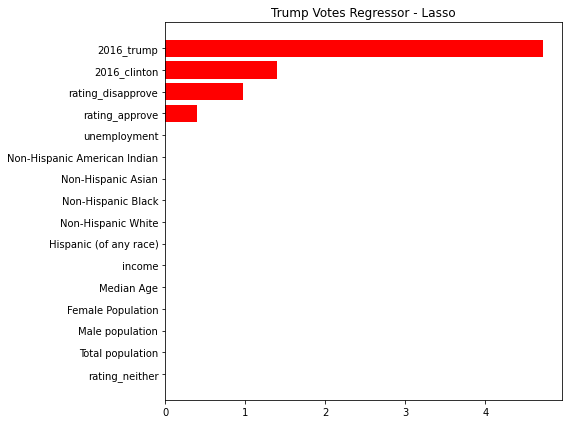

```python
X_train, X_test, y_train, y_test = train_test_split(
        df_features, df['trump'], test_size=0.25, random_state=1)

scaler = StandardScaler()
X_train = scaler.fit_transform(X_train)
X_test = scaler.transform(X_test)

lasso = Lasso(alpha=1)
lasso.fit(X_train, y_train)

coefs = lasso.coef_

top_predictor=df_features.columns[np.argmax(np.abs(coefs))]
abs_coefs = np.abs(coefs)
coefs_count = len(abs_coefs)
fig, ax = plt.subplots(figsize=(8,6))
ax.barh(np.arange(coefs_count), sorted(abs_coefs), color=colors[0])
ax.set_title('Trump Votes Regressor - Lasso')
ax.set_yticks(np.arange(coefs_count))
ax.set_yticklabels(df_features.columns[np.argsort(abs_coefs)]);
plt.tight_layout()
# fig.savefig('importance3.png', transparent=True)
```

For the regression model of Trump's votes, only 4 features are considered -- all belongs to `2016 election results` and `approval rating` -- with 2016 votes for trump being the most important by a huge margin.

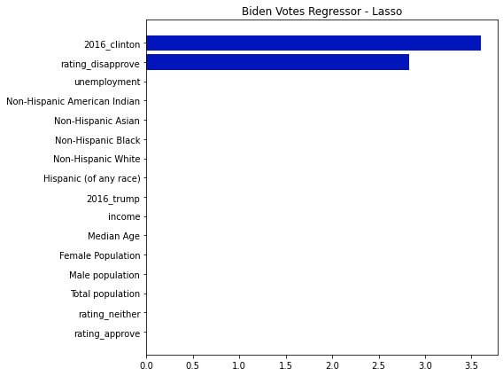

```python
X_train, X_test, y_train, y_test = train_test_split(
        df_features, df['biden'], test_size=0.25, random_state=1)

scaler = StandardScaler()
X_train = scaler.fit_transform(X_train)
X_test = scaler.transform(X_test)

lasso = Lasso(alpha=1)
lasso.fit(X_train, y_train)

coefs = lasso.coef_

top_predictor=df_features.columns[np.argmax(np.abs(coefs))]
abs_coefs = np.abs(coefs)
coefs_count = len(abs_coefs)
fig, ax = plt.subplots(figsize=(8,6))
ax.barh(np.arange(coefs_count), sorted(abs_coefs), color=colors[1])
ax.set_title('Biden Votes Regressor - Lasso')
ax.set_yticks(np.arange(coefs_count))
ax.set_yticklabels(df_features.columns[np.argsort(abs_coefs)]);
plt.tight_layout()
# fig.savefig('importance4.png', transparent=True)
```

Similarly, regression model for Biden's votes uses the same feature but actually considers only two: `Hillary Clinton's 2016 votes` and `amount of disapprove rating`.

The results of Lasso Regression showcases how the algorithm works through feature selection and regularization which enhanced the interpretability. It was able to yield up to 83% R-score by just using just 4 features at most.

## V. Conclusion

Based on the outcome prediction model, states that goes for Trump have a lower `median age`, while states that have high `unemployment rate` and `asian population` are for Biden. The importance of `2016 election results` and `approval ratings` to the canditates' vote prediction also highlights how US states are likely to vote the same party that they went for in 2016 elections, and how Trump administration's current approval ratings can provide an idea of what the poll's outcome will be on each state.

These insights can be valuable to:

1. **The Candidates** - (not only presidential) can utilize Machine Learning to have an idea on how and where to focus their campaign and campaign spending.
2. **Donald Trump, in particular** - as the incumbent candidate, Trump can specifically aim to increase his approval ratings on certain states especially on *swing states*, or those that are known to have regularly seen close contests in past elections.

On the technical side, this study exhibited how linear and logistic regression, regarded as two of the more *basic* machine learning algorithms, can actually provide equal or even better results than more complicated ones such as Random Forest and Gradient Boosting Method -- provided that proper data manipulation and hyperparameters are in place.

## VI. References

[1] USAGov (Jul 2020) - "Presidential Election Process".  
https://www.usa.gov/election

[2] Silver, N (Aug 2020) - "How FiveThirtyEight’s 2020 Presidential Forecast Works — And What’s Different Because Of COVID-19".  
https://fivethirtyeight.com/features/how-fivethirtyeights-2020-presidential-forecast-works-and-whats-different-because-of-covid-19/

[3] FiveThirtyEight (Aug 2020) - "Who’s ahead in the national polls?".  
https://projects.fivethirtyeight.com/polls/president-general/national/

[4] U.S. BUREAU OF LABOR STATISTICS (Aug 2020) - "Local Area Unemployment Statistics LAU LAU Program Links".  
https://www.bls.gov/web/laus/laumstrk.htm

[5] Bureau of Economic Analysis (Jun 2020) - "Personal Income by State".  
https://www.bea.gov/data/income-saving/personal-income-by-state

[6] Civiqs (Aug 2020) - "Donald Trump: Job Approval".  
https://civiqs.com/results/approve_president_trump?annotations=true&uncertainty=true&zoomIn=true

[7] Kaggle (Aug 2020) - "COVID-19 US County JHU Data & Demographics".  
https://www.kaggle.com/headsortails/covid19-us-county-jhu-data-demographics?select=us_county.csv

[8] MIT Election Data and Science Lab (2017) - "U.S. President 1976–2016".  
https://doi.org/10.7910/DVN/42MVDX

[9] Governing (2017) - "State Population By Race, Ethnicity Data".  
https://www.governing.com/gov-data/census/state-minority-population-data-estimates.html

[10] 270towin (NA) - "Split Electoral Votes in Maine and Nebraska".  
https://www.270towin.com/content/split-electoral-votes-maine-and-nebraska https://www.usa.gov/election